# Final

Ngoc Nguyen, Craig Orman

4/29/2022

## Data Selection

This is how we selected our data and ensured it would be small enough to go on github.

```r
HousingOriginal <- read.csv("properties_small_2017.csv")
smallData = HousingOriginal %>% select(yearbuilt, bathroomcnt, airconditioningtypeid, regionidcity, fireplacecnt,
                                       basementsqft, finishedsquarefeet15, landtaxvaluedollarcnt, typeconstructiontypeid, garagetotalsqft,
                                       latitude, longitude, taxvaluedollarcnt)
smallData = smallData %>% filter(bathroomcnt > 0, taxvaluedollarcnt > 999)
samllSampledData = sample_n(smallData, 1000000)
write.csv(samllSampledData,"properties_small_2017.csv", row.names = FALSE)
```

## Instantiation

```r
library(tidyverse)
```

```r
library(ggmosaic)
library(maps)
library(ggplot2)
library(dplyr)
library(broom)
library(ggpubr)
HousingOriginal <- read.csv("properties_small_2017.csv")
```

## Proposal (Homework 11)

Data was acquired from a 2017 kaggle competition, [Zillow Prize: Zillow’s Home Value Prediction (Zestimate)](https://www.kaggle.com/competitions/zillow-prize-1). We specifically used the properties_2017.csv

Project is on [Github](https://github.com/ArgentCode/DS202-final-project).

Our plan is to use the taxvaluedollarcnt as the actual value of the house, and we plan on doing a variety of visualizations and assessments on both the explanatory variables and the response variable. We will be coming at this with a statistics approach as if we were preparing to make a model. We also hope to do a map to visualize the data and see what we can do for that style of visual with coloring and making interesting visuals.

We noticed the data is decently well cleaned. We suspect dealing with the large number of NA’s will be a major challenge, but most of the cleaning has occured in the form of reducing. The original data was an almost 700 mb csv file we had to shrink down (Code above on methodology).

## Actual Report

Real estate and Housing prices are always in great flux. We have decided to use the 2017 Zillow competition data to try and predict prices for real estate using a variety of factors. The response variable we are using will be taxvaluedollarcnt. A continuous quantitative variable.

Quantitative:

yearbuilt, discrete

bathroomcnt, discrete with halves

fireplacecnt, discrete

basementsqft, continuous

finishedsquarefeet15, continuous

landtaxvaluedollarcnt, continuous

garagetotalsqft, continuous

Categorical:

airconditioningtypeid, nominal

regionidcity, nominal

typeconstructiontypeid, nominal

> **Slide 2**:

### Ading expectation for variables:

Craig’s expectations:

yearBuilt: Help explain taxvaluedollarcnt because newer houses will be nicer and have more modern ammenities like outlets

bathroomcnt: Help explain taxvaluedollarcnt because more bathrooms usually is indicative of a bigger house

airconditioningtypeid: I have no idea what the distribution of airconditioning will be. But I am curious to find out.

regionIDCity: Help explain taxvaluedollarcnt because location is often one of the most important factors

fireplacecnt: I do not believe fireplaces are very common these days, so these will be more prevelant in older homes, making them less valuable.

Ngoc’s expectation:

basementsqft: I think basementsqft won’t help explain taxvaluedollarcnt because a lot of houses do not have basements or has not finished it. I think larger houses has larger basement.

typeconstructiontypeid:I don’t think typeconstructiontypeid would well explain taxvaluedollarcnt because the type is not important but areas ( in square feet is). I would like to see if there is any time of construction has the price higher

garagetotalsqft:Bigger house has bigger garage so I think it make sense if this variable is well explain taxvaluedollarcnt.

## Clean and visualize

First, how much data is invalid, and what is the structure of the data

```r
colSums(is.na(HousingOriginal))
```

```
##              yearbuilt            bathroomcnt  airconditioningtypeid
##                   1013                      0                 716490
##           regionidcity           fireplacecnt           basementsqft
##                  18191                 891778                 999469
##   finishedsquarefeet15  landtaxvaluedollarcnt typeconstructiontypeid
##                 939431                      2                 997559
##        garagetotalsqft               latitude              longitude
##                 693812                      0                      0
##      taxvaluedollarcnt
##                      0
```

```r
str(HousingOriginal)
```

```
## 'data.frame':    1000000 obs. of  13 variables:
##  $ yearbuilt             : int  1974 1971 1967 1960 1948 1940 2000 2005 1955 1961 ...
##  $ bathroomcnt           : num  2 3 2 2 2 1 3 3 2 1 ...
##  $ airconditioningtypeid : int  1 1 NA NA NA NA NA 1 NA NA ...
##  $ regionidcity          : int  54311 12447 12447 25218 12447 30399 25218 40227 34780 45602 ...
##  $ fireplacecnt          : int  NA NA NA NA NA NA NA NA NA NA ...
##  $ basementsqft          : int  NA NA NA NA NA NA NA NA NA NA ...
##  $ finishedsquarefeet15  : int  NA NA NA NA NA NA NA NA NA NA ...
##  $ landtaxvaluedollarcnt : num  56256 197955 43465 25549 74957 ...
##  $ typeconstructiontypeid: int  NA NA NA NA NA NA NA NA NA NA ...
##  $ garagetotalsqft       : int  NA NA NA 496 NA NA 511 NA 400 NA ...
##  $ latitude              : int  34398999 34218642 34282598 33721484 34260037 33975641 33718773 34561046 33754225 33998440 ...
##  $ longitude             : int  -118542351 -118565919 -118486224 -117996816 -118293205 -118190332 -118037741 -118164728 -117967234 -117951463 ...
##  $ taxvaluedollarcnt     : num  181921 381763 108887 68536 165987 ...
```

The variables airconditioningtypeid, fireplacecnt, basementsqft, finishedsquarefeet15, typeconstructiontypeid, garagetotalsqft all have a large majority of null values. fireplacecnt uses null to indicate that there is no fireplace. basementsqft uses null to indicate that some houses do not have basement (most of the houses in CA do not) and some basements haven’t finished. However, garagetotalsqft and airconditioningtypeid have a category for no air conditioner so there is no obvious explanation for the lack of values. One possibility is those houses hasn’t finished the garage and AC yet. We still have ~300,000 observations so analysis should be able to continue.

All data is in numeric or integer format which is consistent with the Kaggle competition

Response Variable:

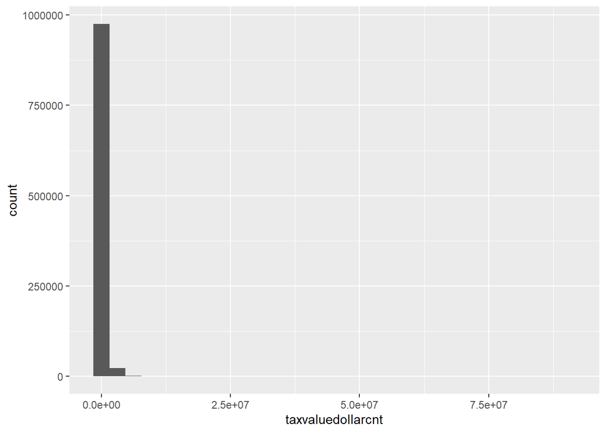

```r
HousingOriginal %>% ggplot(aes(x=taxvaluedollarcnt)) + geom_histogram()
```

```r
HousingOriginal$taxvaluedollarcnt %>% summary()
```

```
##     Min.  1st Qu.   Median     Mean  3rd Qu.     Max.
##     1000   193246   324228   440530   515239 90188462
```

```r
mean(HousingOriginal$taxvaluedollarcnt)
```

```
## [1] 440529.9
```

```r
sd(HousingOriginal$taxvaluedollarcnt)
```

```
## [1] 604003.5
```

```r
HousingOriginal[HousingOriginal$taxvaluedollarcnt > 10000000, ] %>% count()
```

```
##     n
## 1 406
```

```r
HousingOriginal[HousingOriginal$taxvaluedollarcnt < 100000, ] %>% count()
```

```
##        n
## 1 103500
```

> **Slide 4**:

# Visual summary

### Quantitative Explanatory Variables:

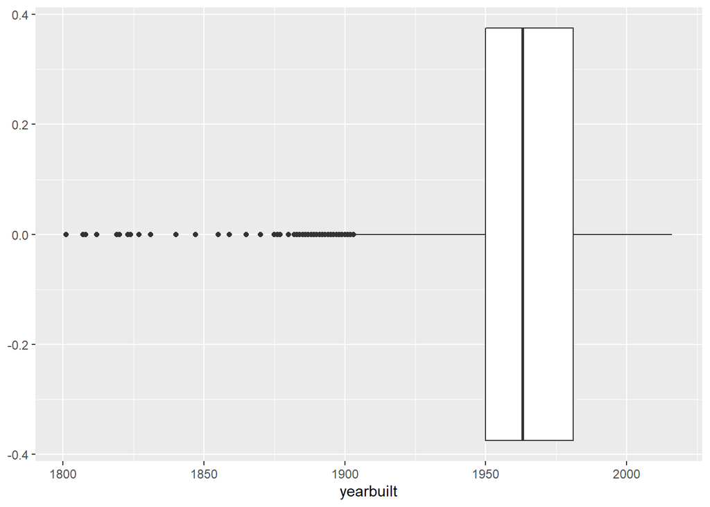

```r
HousingOriginal %>% ggplot(aes(x=yearbuilt)) + geom_boxplot()
```

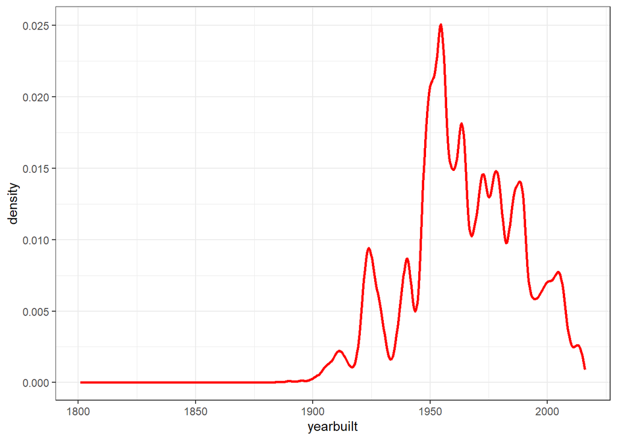

```r
HousingOriginal %>%
  ggplot(aes(x=yearbuilt))+
  geom_line(stat="density", color="Red", size=1)+
  theme_bw()
```

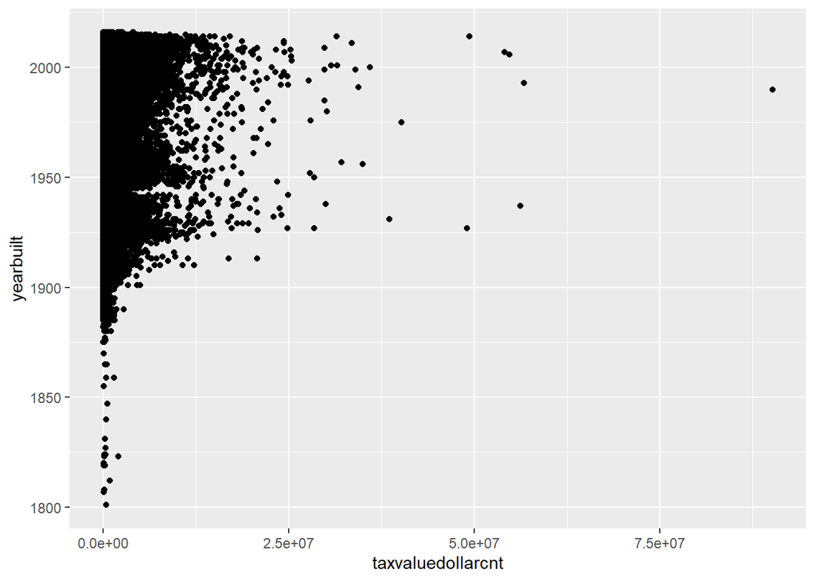

```r
HousingOriginal %>% ggplot(aes(x=taxvaluedollarcnt, y=yearbuilt)) + geom_point()
```

```r
HousingOriginal$yearbuilt %>% summary()
```

```
##    Min. 1st Qu.  Median    Mean 3rd Qu.    Max.    NA's
##    1801    1950    1963    1964    1981    2016    1013
```

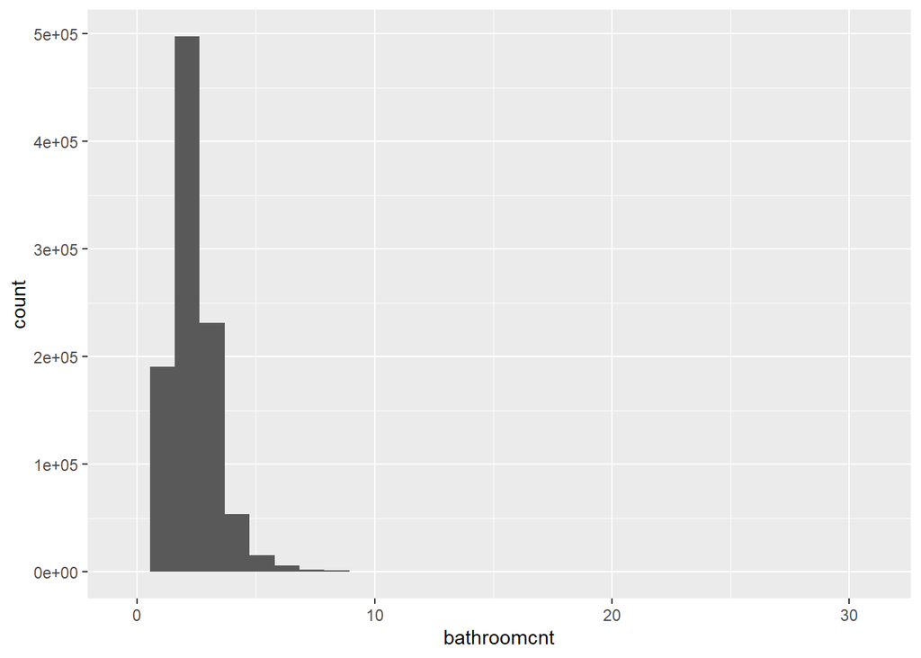

```r
HousingOriginal %>% ggplot(aes(x=bathroomcnt)) + geom_histogram()
```

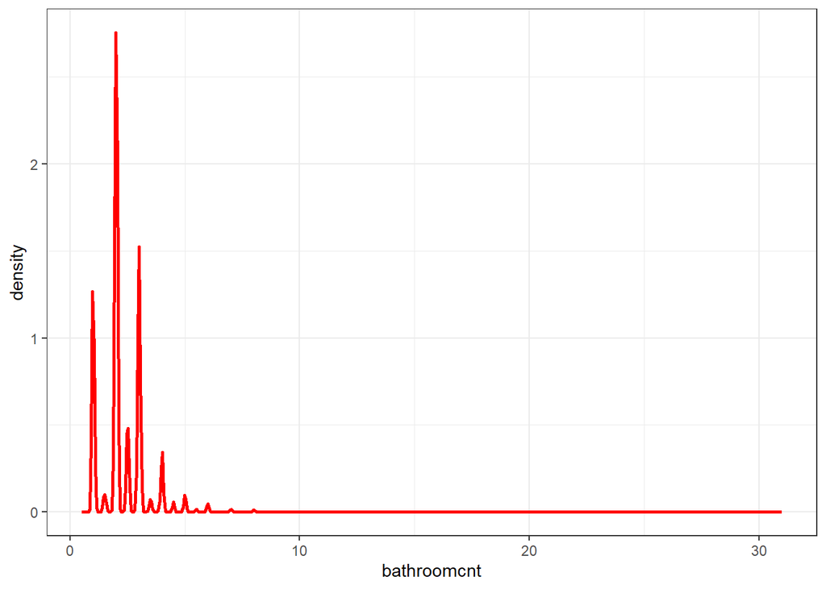

```r
HousingOriginal %>%
  ggplot(aes(x=bathroomcnt))+
  geom_line(stat="density", color="Red", size=1)+
  theme_bw()
```

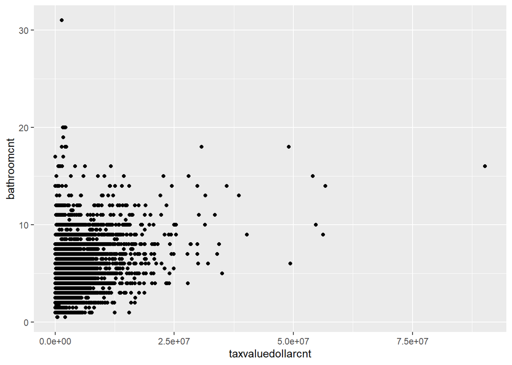

```r
HousingOriginal %>% ggplot(aes(x=taxvaluedollarcnt, y=bathroomcnt)) + geom_point()
```

```r
HousingOriginal$bathroomcnt %>% summary()
```

```
##    Min. 1st Qu.  Median    Mean 3rd Qu.    Max.
##   0.500   2.000   2.000   2.303   3.000  31.000
```

```r
cor(HousingOriginal$taxvaluedollarcnt, HousingOriginal$bathroomcnt)
```

```
## [1] 0.4583753
```

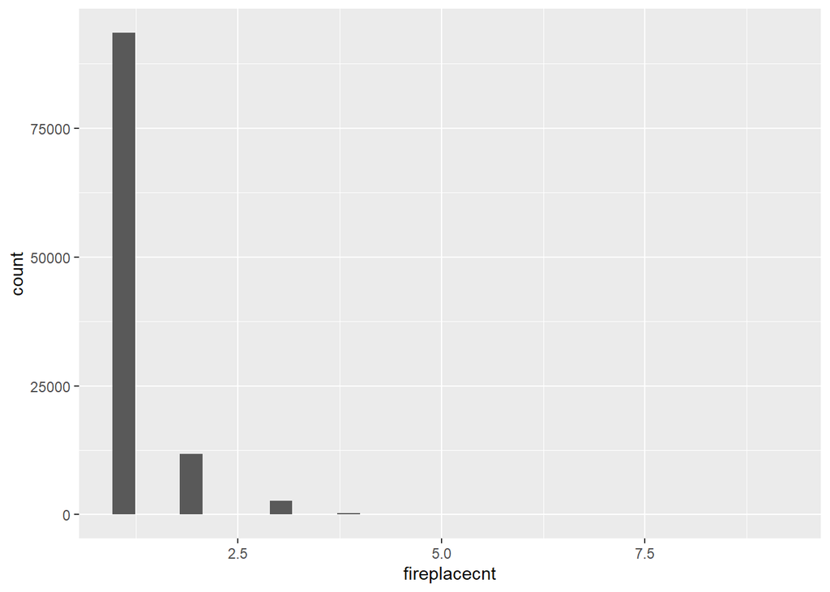

```r
HousingOriginal %>% ggplot(aes(x=fireplacecnt)) + geom_histogram()
```

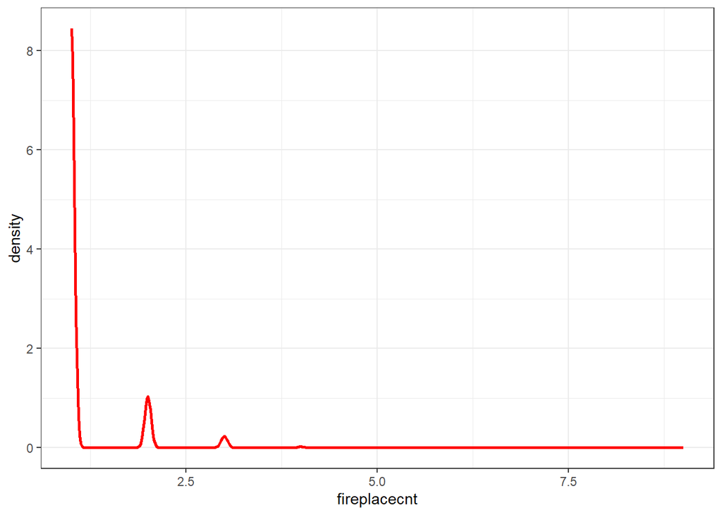

```r
HousingOriginal %>%
  ggplot(aes(x=fireplacecnt))+
  geom_line(stat="density", color="Red", size=1)+
  theme_bw()
```

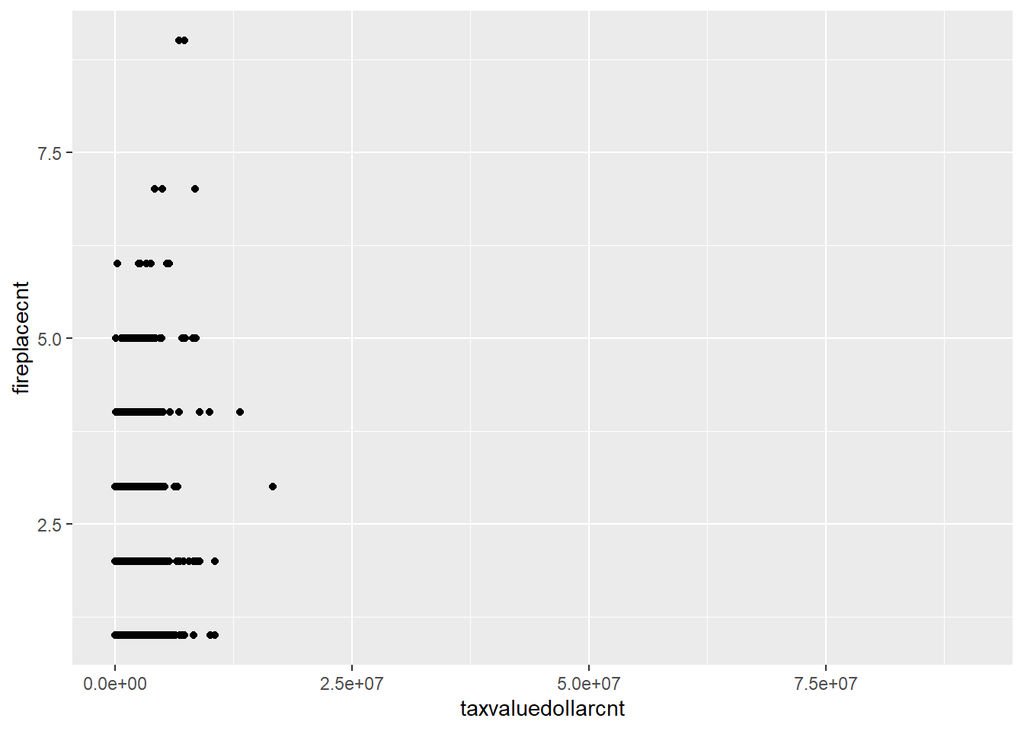

```r
HousingOriginal %>% ggplot(aes(x=taxvaluedollarcnt, y=fireplacecnt)) + geom_point()
```

```r
HousingOriginal$fireplacecnt %>% summary()
```

```
##    Min. 1st Qu.  Median    Mean 3rd Qu.    Max.    NA's
##     1.0     1.0     1.0     1.2     1.0     9.0  891778
```

2 sentences summary: As predicted, most of the observations have no fireplace. Results look logarithmic and very sporadic, there does not appear to be a correlation between fireplacecnt and taxvaluedollarcnt.

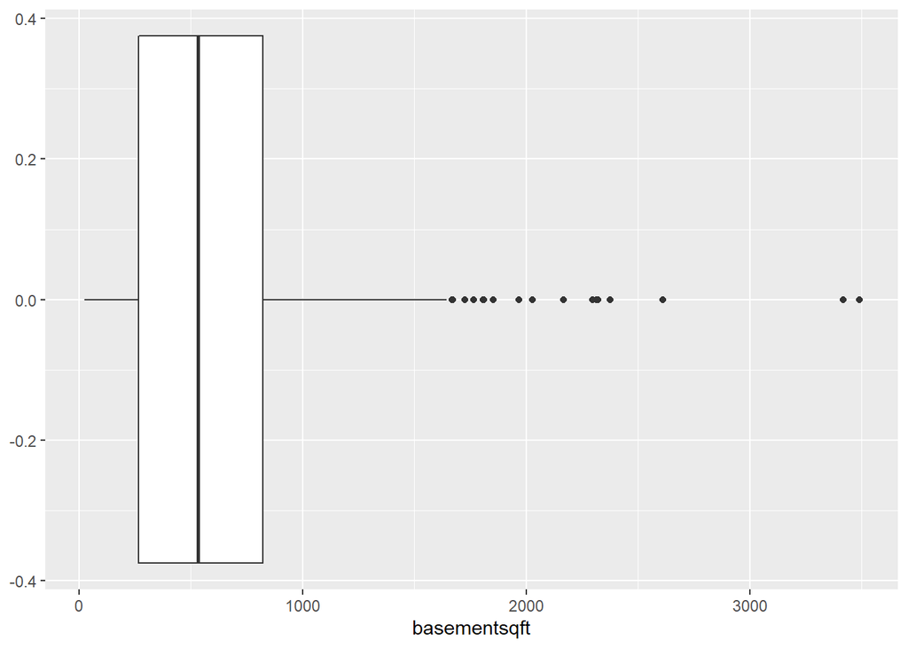

```r
HousingOriginal %>% ggplot(aes(x=basementsqft)) + geom_boxplot()
```

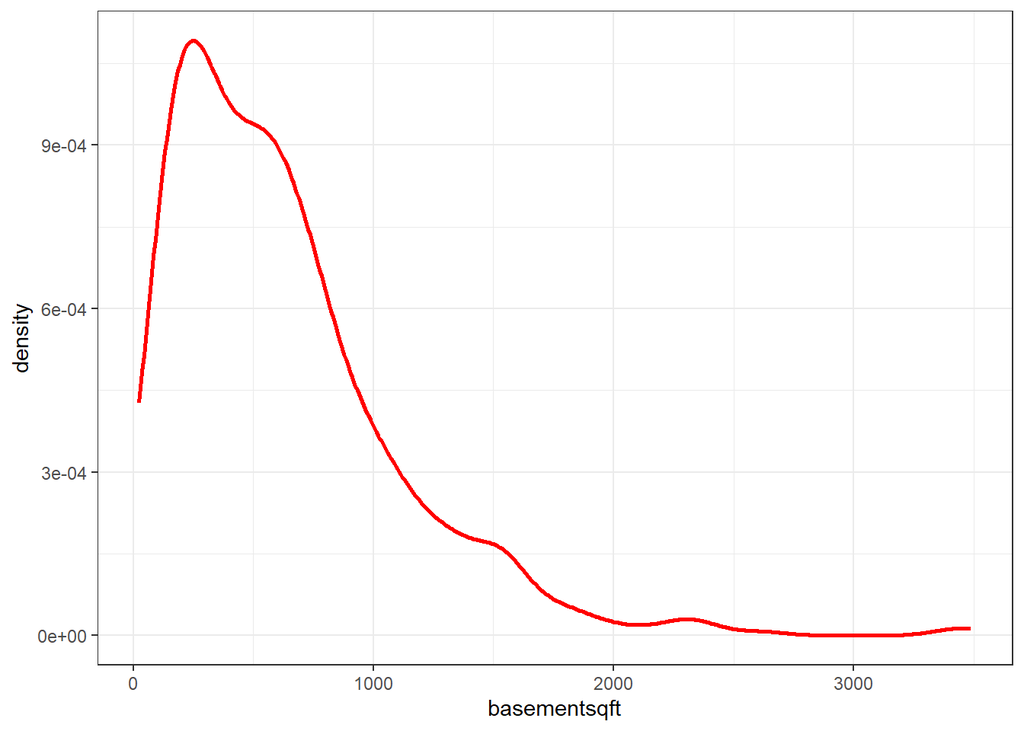

```r
HousingOriginal %>%
  ggplot(aes(x=basementsqft))+
  geom_line(stat="density", color="Red", size=1)+
  theme_bw()
```

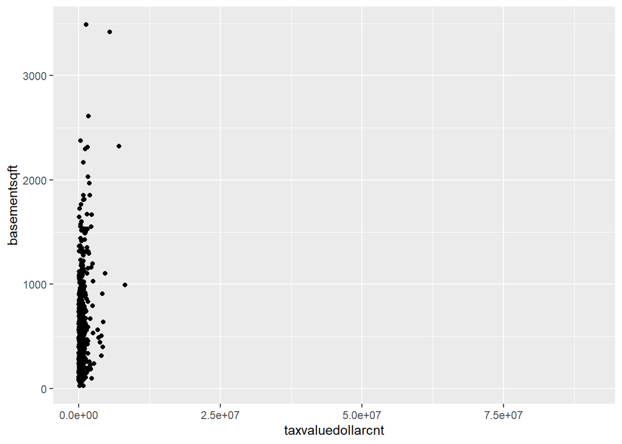

```r
HousingOriginal %>% ggplot(aes(x=taxvaluedollarcnt, y=basementsqft)) + geom_point()
```

```r
HousingOriginal$basementsqft %>% summary()
```

```
##    Min. 1st Qu.  Median    Mean 3rd Qu.    Max.    NA's
##    24.0   266.0   533.0   627.0   823.5  3489.0  999469
```

```r
cor(HousingOriginal$taxvaluedollarcnt, HousingOriginal$basementsqft)
```

```
## [1] NA
```

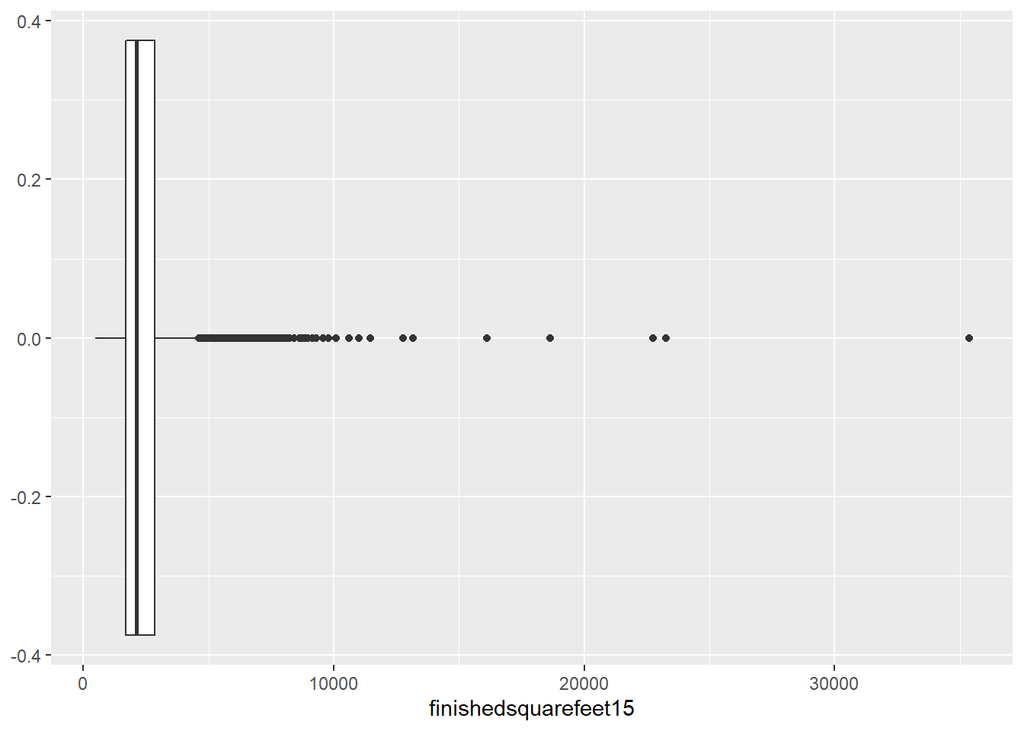

```r
HousingOriginal %>% ggplot(aes(x=finishedsquarefeet15)) + geom_boxplot()
```

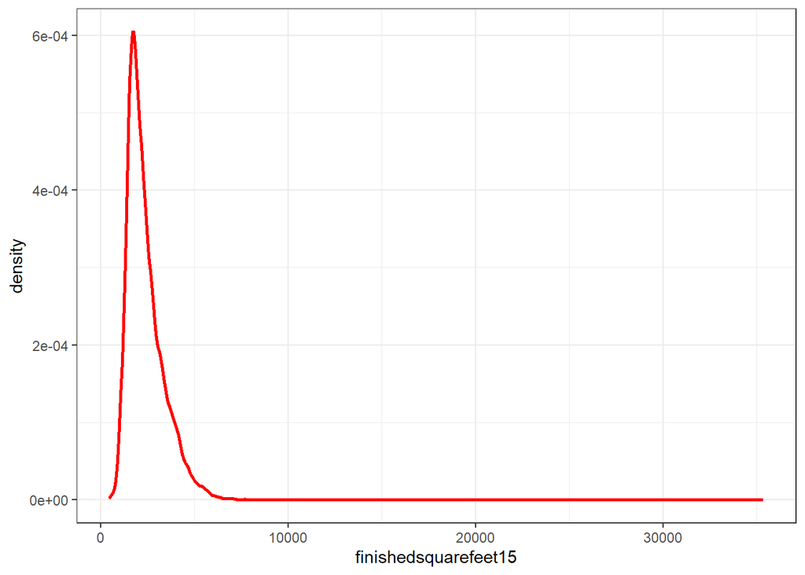

```r
HousingOriginal %>%
  ggplot(aes(x=finishedsquarefeet15))+
  geom_line(stat="density", color="Red", size=1)+
  theme_bw()
```

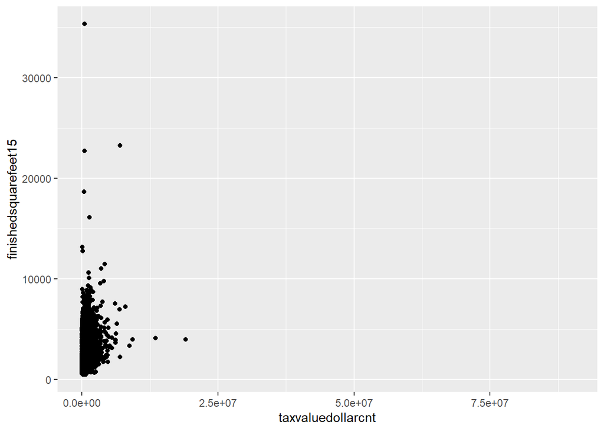

```r
HousingOriginal %>% ggplot(aes(x=taxvaluedollarcnt, y=finishedsquarefeet15)) + geom_point()
```

```r
HousingOriginal$finishedsquarefeet15 %>% summary()
```

```
##    Min. 1st Qu.  Median    Mean 3rd Qu.    Max.    NA's
##     460    1681    2128    2377    2847   35360  939431
```

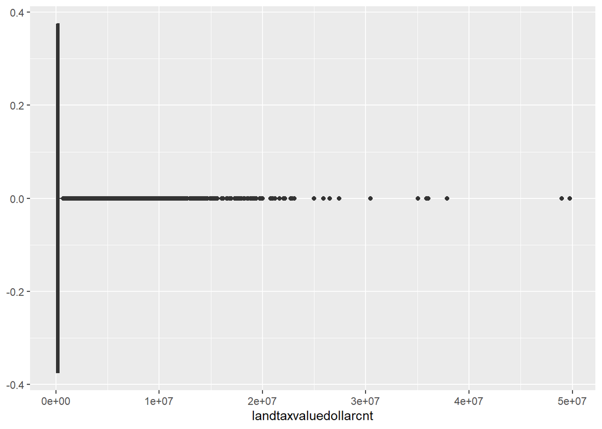

```r
HousingOriginal %>% ggplot(aes(x=landtaxvaluedollarcnt)) + geom_boxplot()
```

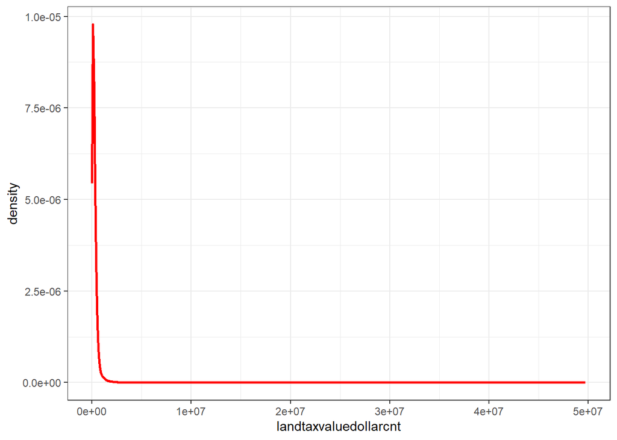

```r
HousingOriginal %>%
  ggplot(aes(x=landtaxvaluedollarcnt))+
  geom_line(stat="density", color="Red", size=1)+
  theme_bw()
```

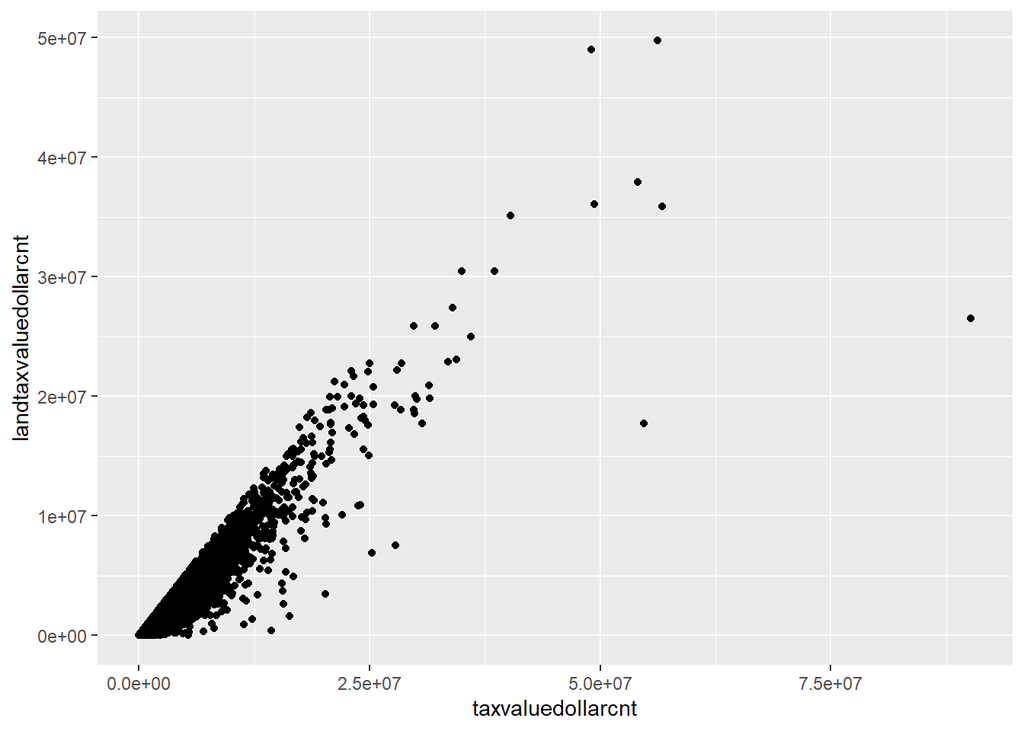

```r
HousingOriginal %>% ggplot(aes(x=taxvaluedollarcnt, y=landtaxvaluedollarcnt)) + geom_point()
```

```r
HousingOriginal$landtaxvaluedollarcnt %>% summary()
```

```
##     Min.  1st Qu.   Median     Mean  3rd Qu.     Max.     NA's
##       89    80267   176660   264983   325091 49733753        2
```

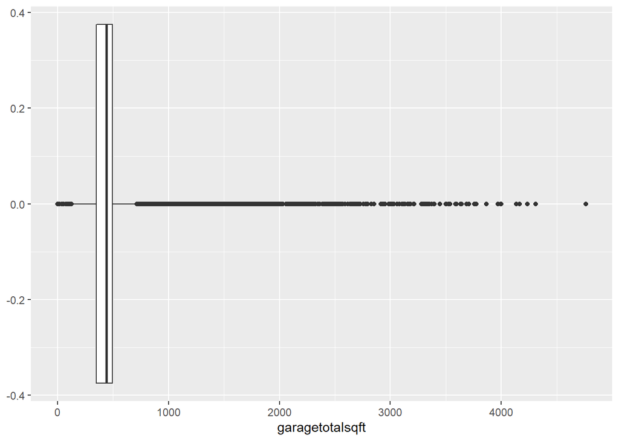

```r
HousingOriginal %>% ggplot(aes(x=garagetotalsqft)) + geom_boxplot()
```

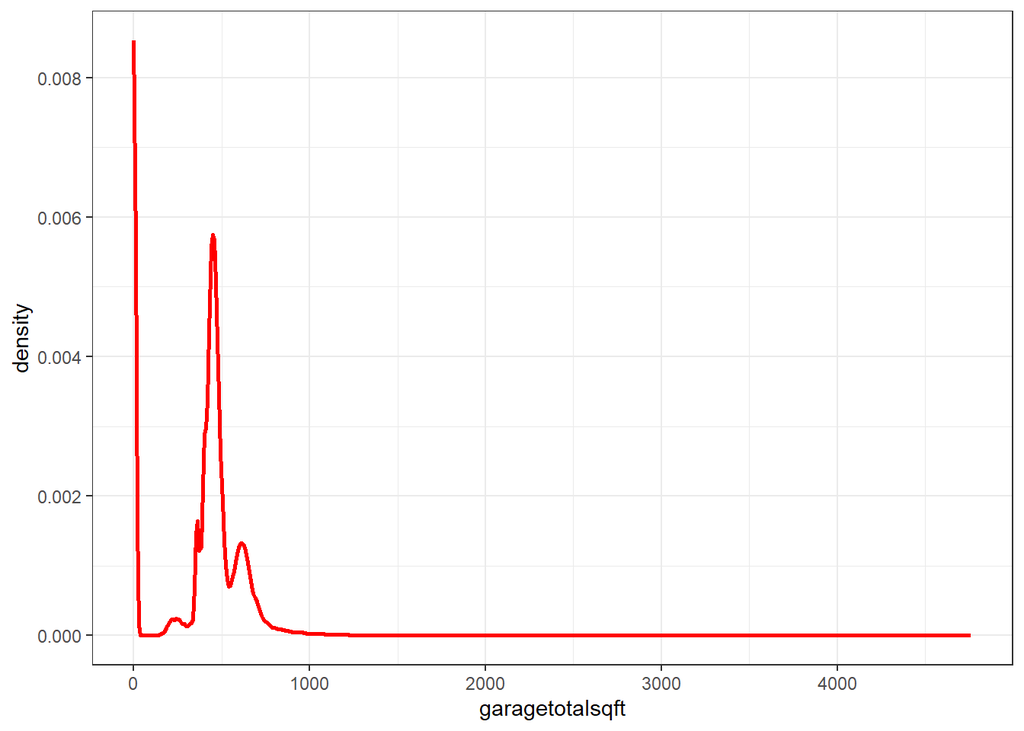

```r
HousingOriginal %>%
  ggplot(aes(x=garagetotalsqft))+
  geom_line(stat="density", color="Red", size=1)+
  theme_bw()
```

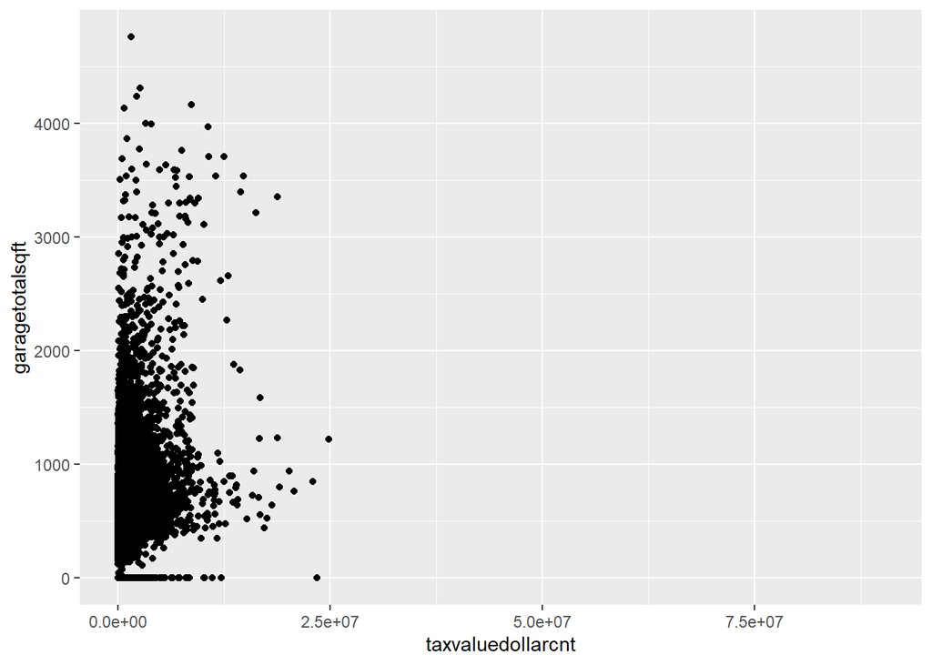

```r
HousingOriginal %>% ggplot(aes(x=taxvaluedollarcnt, y=garagetotalsqft)) + geom_point()
```

```r
HousingOriginal$garagetotalsqft %>% summary()
```

```
##    Min. 1st Qu.  Median    Mean 3rd Qu.    Max.    NA's
##     0.0   350.0   441.0   387.1   496.0  4760.0  693812
```

```r
cor(HousingOriginal$taxvaluedollarcnt, HousingOriginal$garagetotalsqft)
```

```
## [1] NA
```

### Categorical Explanatory Variables:

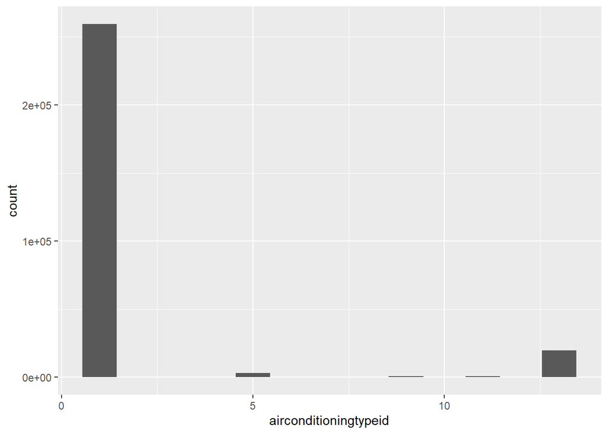

```r
HousingOriginal %>% ggplot(aes(x=airconditioningtypeid)) + geom_bar()
```

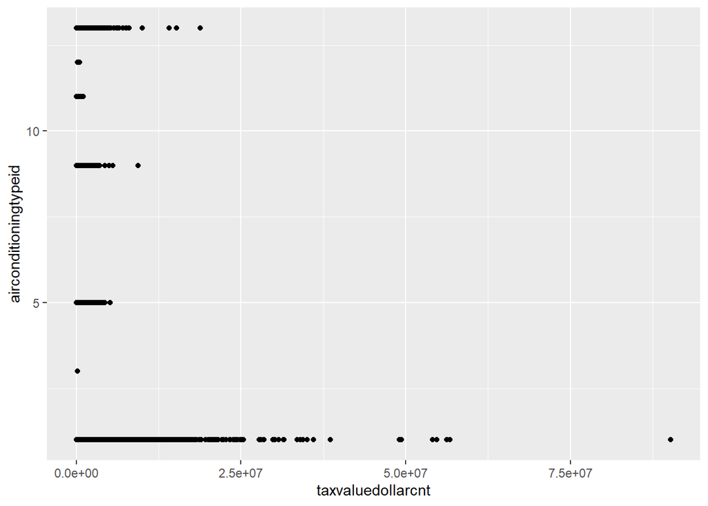

```r
HousingOriginal %>% ggplot(aes(x=taxvaluedollarcnt, y=airconditioningtypeid)) + geom_point()
```

2 sentences summary: Almost all of the observations are of one type. Most of the other types aren’t even visible.

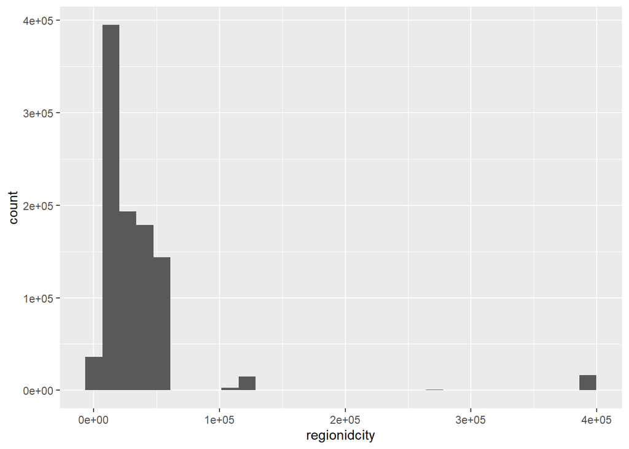

```r
HousingOriginal %>% ggplot(aes(x=regionidcity)) + geom_histogram()
```

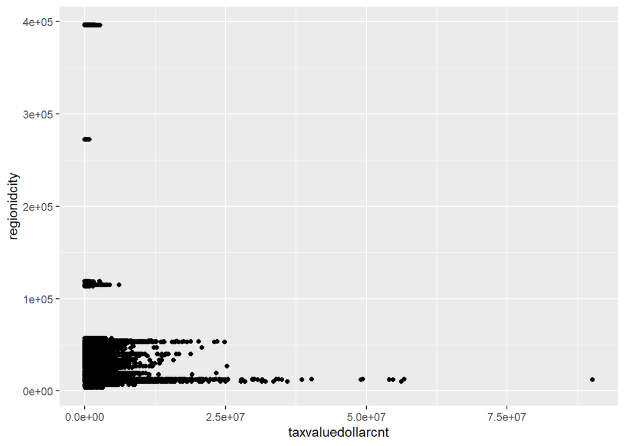

```r
HousingOriginal %>% ggplot(aes(x=taxvaluedollarcnt, y= regionidcity)) + geom_point()
```

2 sentences summary: Data is surprisingly unimodal in a way. Large portion of the data is distributed across a few very similar codes.

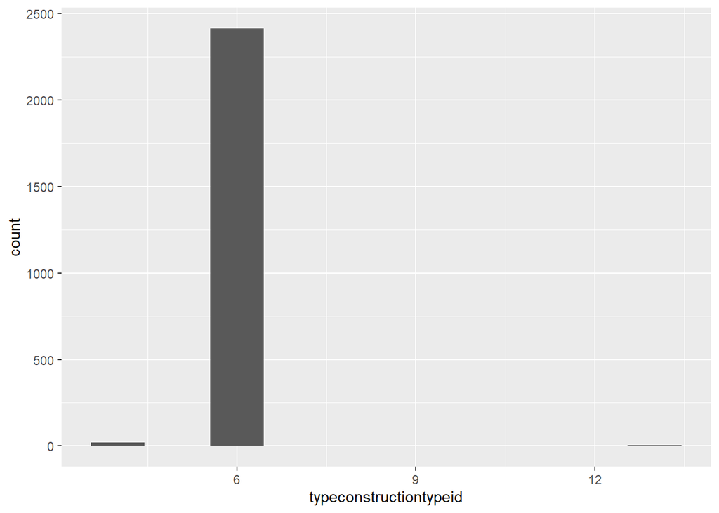

```r
HousingOriginal %>% ggplot(aes(x=typeconstructiontypeid)) + geom_bar()
```

```r
HousingOriginal$typeconstructiontypeid %>% summary()
```

```
##    Min. 1st Qu.  Median    Mean 3rd Qu.    Max.    NA's
##       4       6       6       6       6      13  997559
```

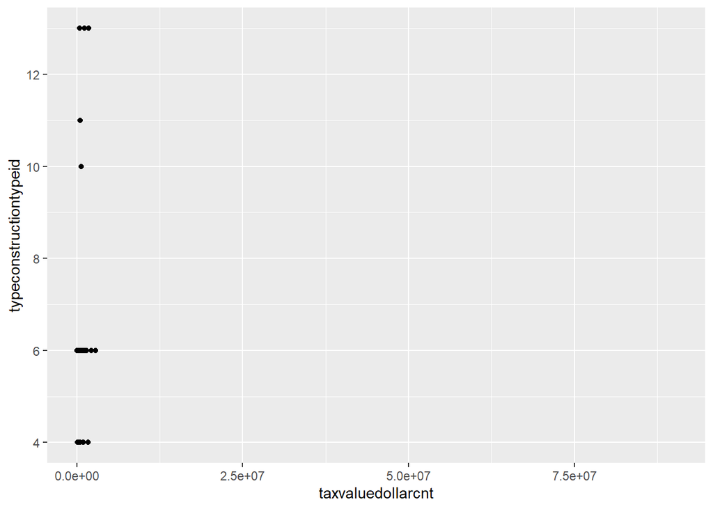

```r
HousingOriginal %>% ggplot(aes(x=taxvaluedollarcnt, y=typeconstructiontypeid)) + geom_point()
```

2 sentences summary: Almost all of the observations are type 6. The rest of the variables are almost invisible.

Next, to get a general sense of what data we are talking about, we will map out the data on a plot. Zillow multiplied all longitudes and latitudes by 1*10e^6 so we accounted for this in the code.

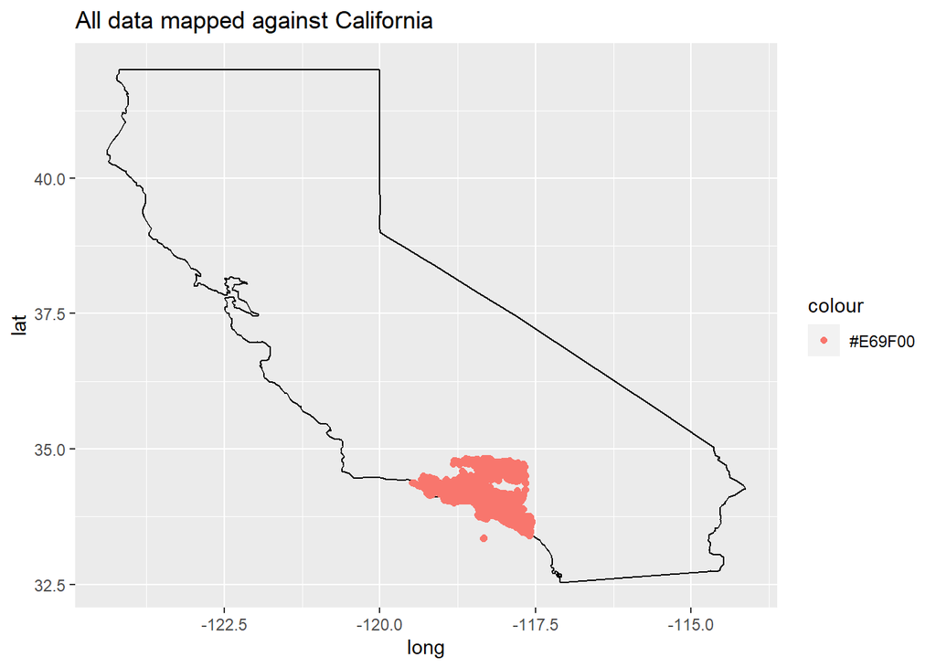

```r
states <- map_data("state")
filter(states, region == "california") %>% ggplot(aes(x = long, y = lat)) +
  geom_path(aes(group = group)) +
  geom_point(data=HousingOriginal,aes(x=longitude/1000000, y=latitude/1000000, color="#E69F00")) +
  ggtitle("All data mapped against California")
```

> **Slide 6**: Expanding complexity